# K-Nearest Neighbors Notes

## *Key Idea:*

[figure not shown]

## *Note*:

-> Always keep ' K ' Odd to avoid ties in class voting

[figure not shown]

## *Failure Cases:*

-> Our data must be well groupes and well seperated else below are some cases where KNN fails,

[figure not shown]

## *Distance Measures used in KNN:*

[figure not shown]

->Hamming distance is used in text featurising especially for detecting similarities b/w strings like human gene (ACTGATCAGTAC....)

## *Cosine Similarity:*

[figure not shown]

## *Space and Time Complexity:*

**Training Time(i.e computing distances not actual training) and Space = O( no_data_pts * dim)**

This is a huge setback for this algorithm !!! as it needs high configured hardware and large amount of time.

Theoretical Improvements,

- Pre-sort training data into fast data structures(like Hash Tables)
- Compute only an approximate distance
- Remove redundant data (condensing)

## *Choice of Nearest Neighbors Algorithm:*

**Query time** or **prediction time** of knn for different algo's are like,

-> **Brute force** :

```
     O( no_data_pts * dim )
```

-> **Ball tree** :

```
    O( log(no_data_pts) * dim)
```

[figure not shown]

-> **kd-tree** :

```
    for dim <= 20, O( log(no_data_pts) * dim)

    else, O( no_data_pts * dim)

    in this case computations are done internally with dimensionality = 2^dim.
```

[figure not shown]

-> in case of **Ball tree** and **kd-tree** to get above query times **'K' must be small**

-> **Brute force** performs well in case of **small no_data_pts and dim**.

## *Choosing the right 'k':*

[figure not shown]

-> First diagram is case of **overfit** with **k = 1** or **a smaller k which isn't suited for out training data** and with this we give importance to noise which is not good.

-> When **k = n** or **k is very near to n** we **underfit** .

-> To choose right 'k' we will use cross validation

## *KNN for Regression:*

-> In this case for each k-NN's we'll have a Real valued number as class label then take,

```
  mean(class labels)

        or

  median(class labels) {less prone to outliers}
```

## *Weighted KNN:*

[figure not shown]

-> above for k = 3 everything is alright

-> lets just say that we found k = 5 is suited for entire data then most likely points like that star are going to be misclassified.

-> solution is to give weights , one way is based on distances.

```
to_decide_class = []

while i < k:

   dist = 1/d(query-pt , i-th-pt)

   append {dist , class of i-th-pt} to 'to_decide_class'

now we'll have 'k' weights(here it's based on distance)

then do 'to_decide_class.group_by(class_label)'

add up all dist for each class label

finally, declare the class with highest weight as class label of query-pt
```

## *Voronoi Diagram:*

-> A special case for k = 1,in below diagram each point have it's own territory / region now when a **query-pt falls anywhere in one of those regions** its 1-NN will be that regional point only.

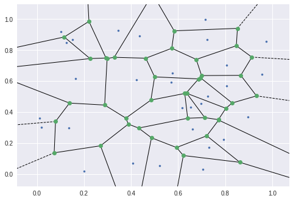

```python
import matplotlib.pyplot as plt
import numpy as np
from scipy.spatial import Voronoi, voronoi_plot_2d

fig = voronoi_plot_2d( Voronoi( np.random.rand(30,2) ) )

plt.show()
```

## *Locality Sensitive Hashing*:

[figure not shown]

-> In reality there can be few points outside the regions 'R'

-> use a Hash Function to place our X-q in one of R's

-> Then select kNN's from set of pts in that R